# Differential item functioning

Peter Halpin

03-03-2023; last updated 03-07-2023

# Intro

Differential item functioning (DIF) addresses the situation where responses to an assessment differ as a function of an external covariate. In many cases, the external covariate is a pre-existing socio-demographic variable (e.g., gender, race, first language). In the context of test development, the main purpose of DIF analysis is to make sure items on an assessment are not biased with respect to these kinds of pre-existing social groups.

In these notes we will focus on DIF for the 2PL model in two independent groups of respondents (e.g., males vs females; “white” vs “non-white”). There are many extensions of DIF methodology to include multiple types of other covariates (categorical, continuous, longitudinal) and to include other types of IRT models (ordered categorical, multidimensional). There are also many ways of testing DIF in each of these situations, ranging from “model-free” methods based on contingency tables (e.g., the Mantel-Haenszel test), methods based on models other than IRT (e.g., logistic regression, structural equation models with item covariates), model fit using IRT (e.g, LR tests or score-based tests), methods that combine IRT with machine learning (e.g., Lasso or other methods for penalizing model parameters), etc., etc.

Regardless of the method used, the definition of the problem is the same. So we will start there. Then we will move on to discuss two widely used methods that illustrate some main issues and serve as a starting point for self-study of other methods.

Before getting started it is important to note at the outset that nearly all methods of DIF analysis assume that either (a) only small proportion of items on an assessment exhibit (e.g., $\leq 10\%$) or (b) some items without DIF can be identified ahead of time (called “anchors”). When neither of these conditions holds, most DIF methods can fail badly. Recent research has addressed this problem, see the subsection of the references entitled “DIF Without Anchors” for more readings.

# Defining the problem

Let $p({\bf X} \mid W)$ denote the probability distribution of the $J$-dimensional response pattern ${\bf X} = (X_1, \dots, X_J)$, conditional on an external covariate, $W$. For simplicity, let’s also assume that $W$ can take on only two values, with $0$ denoting the reference group and $1$ denoting the comparison (or focal) group. The choice of these two groups is arbitrary, but, especially in the context of educational testing, the comparison group is usually a socially minoritized group that we worry the test may be biased against.

If it is the case that
$$p({\bf X} \mid W = 1) \neq p({\bf X} \mid W = 0)$$

then the two groups have different distributions of their observed responses (e.g., one group may be more likely to score higher on the test than the other). This is often what lay populations mean by “test bias” – test scores differ over pre-existing social groups.

Psychometric models provides two possible explanations of this situation via the familiar factorization:

$$p({\bf X} \mid W) = \int p({\bf X} \mid \theta, W)p(\theta \mid W) d\theta.$$
If it is the case that

$$\tag{BIAS.2}
p({\bf X} \mid \theta, W = 0) \neq p({\bf X} \mid \theta, W = 1)$$
then the measurement model does not perform the same way across groups. Note that this is a violation of the assumption of conditional independence – i.e., after conditioning on the latent trait, the response data still depend on the external variable. This is what a psychometrician means when they say a test is biased. DIF is about uncovering the source of such bias (i.e. biased items) and removing them from the test.

If the test is unbiased in the psychometric sense, then
$$\tag{BIAS.3}
p({\bf X} \mid \theta, W = 0) = p({\bf X} \mid \theta, W = 1) = p({\bf X} \mid \theta)$$

i.e., the response data are conditionally independent given the latent trait, at least with respect to the particular variable $W$ under consideration. Note that even if the test is unbiased in the psychometric sense, it may yet be biased in the lay sense. Rewriting the familiar factorization under the assumption that the test is psychometrically unbiased, we have

$$p({\bf X} \mid W) = \int p({\bf X} \mid \theta)p(\theta \mid W) d\theta.$$
This equation tells us that, even if the test is psychometrically unbiased, the distribution of the test responses may differ over groups due to differences in the distribution of the construct being measured. In other words, the two groups may have different distributions of $\theta$, even if the test is not biased.

This claim – that pre-existing social groups may differ on the construct being measured – can be quite controversial. This is especially the case in educational settings when $W$ indicates a historically disenfranchised group. However, when such differences exist, they are almost universally interpreted in terms of differences in educational opportunity, not intrinsic differences between group members.

There are also many situations in which the claim that groups may differ on the construct of interest is not controversial. These situations can arise when either (a) the variable $W$ does not indicate a socially protected group (e.g, it could be pre-post testing of the same person in a longitudinal setting) or when the assessment is not high stakes (e.g., self-reports used in non-clinical research settings).

We will get into this conversation during class. For now I will just note that the psychometric term for group differences on the latent trait is “impact” – as in “the grouping variable impacts the distribution of the latent trait.”

In summary, IRT posits two non-mutually exclusive explanations of why groups may differ in the distribution of their test scores: DIF and impact. DIF analysis is about detecting biased test items without making any assumptions about impact. It turns out that this is a very thorny problem for statistical reasons, as well as social reasons.

Before moving on, let’s clarify some related terminology. If no items on a test are biased – i.e., if Equation BIAS.3 is true – then test is said to be *measurement invariant*. If instead Equation BIAS.2 holds, the test is said to be *measurement non-invariant* (lovely double negation). If a test is measurement non-invariant, then it is the case that at least one item exhibits DIF. So, both measurement non-invariance and DIF connote test bias in the psychometric sense. Going forward I will use the term “bias” exclusively to mean psychometric bias, and will use impact to mean group differences in the distribution of the latent trait. We will leave behind the lay notion of bias at this point.

# Why is DIF a hard problem?

Recall that the overall purpose of DIF analysis is to detect biased items without making assumptions about impact. To do this, we want to be able to test whether item parameters differ over groups. As mentioned above, there are lots of ways to do this, and we will see some specific examples in the following sections. The general logic is that, if all of the item parameters are the same in both groups, then measurement model is, by definition, the same in both groups, and so we conclude that the test is not biased with respect to group membership. Sounds simple enough, right? So what is the problem?

The problem has to do with scaling the latent trait. This is like a “mini-version” of rotational indeterminacy that arises when we have unidimensional latent trait. To see how it works, let’s write the 2PL model in logit notation:

$$\tag{2PL}
\text{logit} (P_j(\theta)) = a_j(\theta - b_j).$$

If we used the transformed values $\theta^∗ = A\theta + B$, $b^∗_j = A b_j + B$, and $a^*_j = a_j/A$ in Equation (2PL), this leaves the value of the logit unchanged:

$$\begin{align}
\text{logit} (P_j(\theta)) & = a^*_j(\theta^* - b^*_j) \\
& = \frac{a_j}{A}(A\theta + B - (A b_j + B)) \\
& = a_j(\theta - b_j).
\end{align}$$

Thus, the 2PL IRT is not identified (or, more technically, it is identified only up to a linear transformation of the latent trait). To address this problem, we usually set $E(\theta) = 0$ and $\text{V}(\theta) = 1$ – i.e., we “scale” the latent trait to have mean of zero and variance of one.

(Side note: how does scaling fix the identification problem? The only linear transformation that preserves the mean and variance of a variable is $A = 1$ and $B = 0$. Ask in class if this is confusing.)

So far, so good: We already knew that the latent trait was standardized, and now we have a deeper understanding of why. So, how is this a problem for DIF analysis?

Well, in the case where the external variable is binary, we now have two groups. Therefore we need to scale the latent trait in both groups. If we standardize the latent trait in both groups, we end up saying that both groups have the same mean and same variance – i.e., $E(\theta|W) = 0$ and $\text{V}(\theta \mid W) = 1$. In other words, if we arbitrarily scale the latent trait in both groups, we end up asserting that there is no impact, which is not at all an “arbitrary” assertion. This is called the *multi-group scaling problem*, which we address in more detail next week.

Note that, in general, we want to allow groups to have different population models. Otherwise all groups must have the same distribution of the latent trait, no matter how the groups were formed or what analyses we want to conduct. Thus, the multi-group scaling problem is “bigger” than the DIF problem. It affects DIF, but it also affects other types of analyses.

In the context of two independent groups, the usual way to solve the multi-group scaling problem is to (a) arbitrarily scale the latent trait in only one of the groups, and then (b) assume that some (or all) of the item parameters are equal over groups. Part (a) is warranted because, as noted, IRT models are identified only up to a linear transformation of the latent trait. Part (b) then suffices to scale the latent trait in the second group. We will address how this works in more detail next week, but for now it is sufficient to note that we can scale the latent trait directly (by fixing its mean and variance) or indirectly (by fixing some item parameters).

In the literature on DIF, part (b) of the scaling problem is referred to as choosing an “anchor set” of items (see the Kopf reading). In other words, we need to identify a set of items that do not have DIF in order to scale the latent trait. But … isn’t this exaclty where we started? We started with the problem of how to compare item parameters over groups. And now we have found that, in order to address this problem, we need to assume that some item parameters are equal over groups.

This situation has been referred to as the circular nature of DIF, and is depicted below. We will talk over this issue in more detail in class. It is the big-picture idea behind all DIF methods, and, until recently, there has been no good solution to this problem.

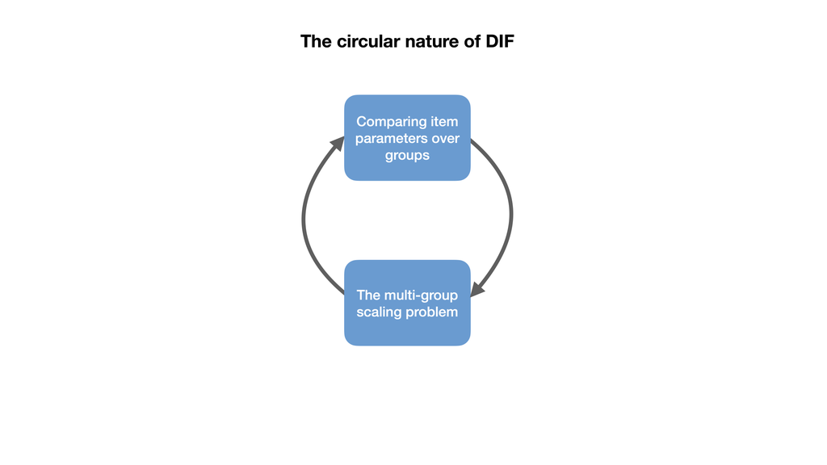

# MH test

The Mantel-Haenszel (MH) test for DIF is widely used in educational testing (i.e., dichotomous scored items). The test itself was introduced in 1959, and was later adapted to the context of DIF by Paul Holland (1985; see Holland and Wainer 1993 for discussion). It is not based on IRT directly (i.e., it is used more widely), but the test statistic has been analyzed under various IRT models.

The test involves matching respondents in the reference and comparison group on the latent variable, or a proxy thereof. Often, the matching variable is a total score on the test. Once the individuals in both groups have been matched on the total score, the test compares the odds of endorsing the item across each of the matched strata using the odds ratio.

The table below illustrates the main ideas of the MH test.

|  | Reference | group | Comparison | group | Odds Ratio |
| --- | --- | --- | --- | --- | --- |
| **Focal item:** | $X_j = 0$ | $X_j = 1$ | $X_j = 0$ | $X_j = 1$ |  |
| $M = 1$ | $R_{01} \;$ | $\; R_{11}$ | $C_{01} \;$ | $\; C_{11}$ | $(R_{11} / R_{01}) / (C_{11} / C_{01})$ |
| $M = 2$ | $R_{02} \;$ | $\; R_{12}$ | $C_{02} \;$ | $\; C_{12}$ | $(R_{12} / R_{02}) / (C_{12} / C_{02})$ |
| $M = 3$ | $R_{03} \;$ | $\; R_{13}$ | $C_{03} \;$ | $\; C_{13}$ | $(R_{13} / R_{03}) / (C_{13} / C_{03})$ |
| $\dots$ | $\dots$ | $\dots$ | $\dots$ | $\dots$ | $\dots$ |

- The reference and comparison groups are the levels of the external variable (denoted $W$ above).
- The focal item is the item that we want to test for DIF.
- $M$ denotes the levels of the matching variable.
- The letters $R$ and $C$ denote the number of respondents who answer the item incorrectly (0) or correctly (1) in each stratum of the matching variable.
- In each stratum the odds of answer the item correctly in the reference group are $R_{1m} / R_{0m}$. Similarly for the comparison group.
- The odds ratio is computed as the ratio of the odds: $OR_m = (R_{1m} / R_{0m}) / (C_{1m} / C_{0m})$

The null hypothesis of the MH test is that, within each stratum of the matching variable, the odds of answering the focal item correctly in the reference and comparison group are equal:

$$H_0: R_{1m} / R_{0m} = C_{1m} / C_{0m} \quad \text{for } m = 1 \dots M,$$
or, equivalently, that the odds ratio is equal to one in each stratum

$$H_0: OR_m = 1 \quad \text{for } m = 1 \dots M.$$
The MH test compares test the null hypothesis against the alternative hypothesis that the OR is constant across strata, but not equal to 1.

The MH procedure is the uniformly most powerful test against the constant OR alternative. The test statistic itself is not especially interpretable to look at, but it is accompanied by an estimate of the constant OR, $\alpha$:

$$\hat \alpha = \frac{\sum_{m=1}^MR_{1m} C_{0m} / N_m}{\sum_{m=1}^M R_{0m} C_{1m} / N_m},$$
which can be reported as an effect size. It is also common to report the effect size in the “delta” metric used by ETS which, which transforms the OR into a difference in difficulty parameters, where positive values indicate that the item was easier in the comparison group.

## Illustration

The R library `difR` provides many of the procedures for testing DIF outlined in the Teresi et al reading (see Magis et al. 2010 for documentation on the package). Here we will use `difR` to compute the MH test for the learning items using country (Mexico or Palestine) as the grouping variable.

```r
# load and merge data files
path_to_mex_data <- "~/Dropbox/Academic/Teaching/UNC/EDUC_787/Data/ECDI_learning.csv"
path_to_pal_data <- "~/Dropbox/Academic/Teaching/UNC/EDUC_787/Data/ECDI_learning2.csv"
mex.dat <- read.csv(path_to_mex_data)
pal.dat<- read.csv(path_to_pal_data)
dat <- rbind(mex.dat, pal.dat)
country <- c(rep("mex", times = nrow(mex.dat)), rep("pal", times = nrow(pal.dat)))

# MH test via difR package
# install.packages("difR")
library(difR)
difMH(dat, country, "pal")
```

```
##
## Detection of Differential Item Functioning using Mantel-Haenszel method
## with continuity correction and without item purification
##
## Results based on asymptotic inference
##
## Matching variable: test score
##
## No set of anchor items was provided
##
## No p-value adjustment for multiple comparisons
##
## Mantel-Haenszel Chi-square statistic:
##
##       Stat.   P-value
## ECD05  0.0669  0.7958
## ECD06 17.6640  0.0000 ***
## ECD07  6.4470  0.0111 *
## ECD08 36.4403  0.0000 ***
## ECD09  0.7622  0.3827
## ECD10 69.4841  0.0000 ***
## ECD11 41.0047  0.0000 ***
## ECD12  0.0026  0.9595
## ECD13  2.9393  0.0864 .
## ECD14 83.3906  0.0000 ***
## ECD15 40.4858  0.0000 ***
##
## Signif. codes: 0 '***' 0.001 '**' 0.01 '*' 0.05 '.' 0.1 ' ' 1
##
## Detection threshold: 3.8415 (significance level: 0.05)
##
## Items detected as DIF items:
##
##  ECD06
##  ECD07
##  ECD08
##  ECD10
##  ECD11
##  ECD14
##  ECD15
```

[output cut: 11 more lines]

```
## ECD06  0.4624  1.8126 C
## ECD07  0.7286  0.7439 A
## ECD08  0.4423  1.9172 C
## ECD09  0.8241  0.4547 A
## ECD10  4.4543 -3.5106 C
## ECD11  2.6729 -2.3105 C
## ECD12  0.9876  0.0293 A
## ECD13  1.2189 -0.4653 A
## ECD14  0.3118  2.7387 C
## ECD15  1.9611 -1.5827 C
##
## Effect size codes: 0 'A' 1.0 'B' 1.5 'C'
##  (for absolute values of 'deltaMH')
##
## Output was not captured!
```

## Further comments

Some additional notes on the MH test:

- As mentioned, the MH test is uniformly most powerful against the alternative hypothesis that the OR is equal to a constant across strata of the matching variable. This alternative hypothesis (constant OR) is commonly referred to as “uniform” DIF. In the 2PL model, uniform DIF translates into group differences in the difficulty parameter, but not the discrimination parameter. In other words, tests of uniform DIF assume that items can differ across groups in their difficulty but not their discrimination. When there may be differences in both parameters, the rationale for using the MH test is not clear, and often other test are used in this situation.
- How to choose the matching variable? If some of the items are biased, then surely we should not match the groups using these biased items, since we would be “baking-in” the bias when computing the matching variable. But, how can we know which items are (or are not) biased before testing for DIF? This is where the “circular logic” of DIF shows up, and it has no analytically satisfactory answer.
  - Early research suggested conducting the MH test in two stages. The first stage (“refinement”), as conducted above, identifies any items that may have DIF and these items are dropped from the matching variable. The second stage (“purification”) runs the entire procedure again with the “refined” matching variable (see the `purify` option in `difMH`). Simulation studies have shown that this can work OK if only a small proportion of items exhibit DIF (e.g., Zwick, 1993)
  - The problem of deciding which items should go into the matching variable led to a more general version of the problem: anchor item selection. The Kopf et al. (2015) reading discusses many approaches to this problem. These approaches all suffer from the same circular logic, and, moreover, subsequent tests of DIF act as if the anchors were known a’priori.

# LR test

The LR test use a multi-group IRT model to test whether the parameters of an item differ over groups. This test is applicable to any IRT model, and to any type of DIF (uniform or otherwise). However, it is subject to the same concerns about anchor item selection mentioned above: We need to choose a set of items that are considered not to have DIF when testing which items do have DIF.

Let’s write the 2PL in two groups as follows:

$$\begin{align}
\text{Reference group: } & \text{logit} (P_{j0}(\theta)) = a_{j0}(\theta - b_{j0}) \quad \text{ with } \theta \sim N(0, 1) \\
\text{Comparison group: } & \text{logit} (P_{j1}(\theta)) = a_{j1}(\theta - b_{j1}) \quad \text{ with } \theta \sim N(\mu, \sigma) \\
\end{align}$$

The second subscript on the IRFs and item parameters indicates the reference group (0) or the comparison group (1). In the reference group, we scale the latent trait arbitrarily (usually, standardized to have$E(\theta) = 0$ and $V(\theta) = 1$). In the comparison group we estimate the mean the variance of the latent trait. This rationale for this set up was discussed above when addressing the multi-group scaling problem.

In order to apply the LR test we compare the following two models.

- The nested (smaller) model is obtained by setting all item parameters equal across groups:

$$a_{j0} = a_{j1} = a_{j} \quad \text{ and } \quad b_{j0} = b_{j1} = b_j \quad \text{for all } \quad j = 1 \dots J.$$

- The nesting (larger) model is obtained by allowing the parameters of the focal item to vary across groups:

$$a_{j0} \neq a_{j1} \quad \text{ and } \quad b_{j0} \neq b_{j1} \quad \text{for the focal item } j^*.$$
Note that in the nesting model, we are not requiring the items to be unequal – they may be equal or unequal, and we simply allow them to be estimated freely in each group.

The LR test then proceeds as usual – i.e., we compare the nested model the to nesting model using the LR test. When the constraints imposed by the nested model are valid (i.e., if there is no DIF), this test has a chi-square distribution with degrees of freedom equal to the number of constrained parameters.

- If the LR test of DIF is significant, we conclude that the item is biased.
- If not, then we conclude that the item is not biased.

For an effect size, one can compare the parameter estimates in the two models or plot the IRFs.

## Illustration

`mirt` implements various IRT-based DIF procedures using the `DIF` function. In order to use this function, we must first estimate the appropriate multigroup IRT model using the `multipleGroup` function. note that the default parameterization for the `multipleGroup` function is to standardize the latent variable in both groups (i.e., assume no impact) and that these defaults can be overridden using the `invariance` argument. The example below uses the same data as for the MH test. Note that `DIF` does not provide an effect size but you can request it to return nesting models (`return_models = T`).

```r
library(mirt)
# model with slopes and intercepts fixed, mean and variance of theta free
invariance <- c("free_mean", "free_var", "slopes", "intercepts")
mod <- multipleGroup(dat,
                     model = 1,
                     group = country,
                     itemtype = "2PL" ,
                     invariance = invariance,
                     verbose = F)

# uniform DIF
(uniform <- DIF(mod, which.par = c("d"), scheme = "drop"))
```

```
##       converged     AIC   SABIC      HQ     BIC     X2 df     p
## ECD05      TRUE  -0.001   2.737   2.136   5.914  2.001  1 0.157
## ECD06      TRUE  -6.608  -3.870  -4.471  -0.693  8.608  1 0.003
## ECD07      TRUE  -1.870   0.869   0.268   4.046  3.870  1 0.049
## ECD08      TRUE -24.167 -21.429 -22.029 -18.251 26.167  1 0.000
## ECD09      TRUE   0.667   3.405   2.805   6.583  1.333  1 0.248
## ECD10      TRUE -97.312 -94.573 -95.174 -91.396 99.312  1 0.000
## ECD11      TRUE -47.723 -44.984 -45.585 -41.807 49.723  1 0.000
## ECD12      TRUE   1.935   4.674   4.073   7.851  0.065  1 0.799
## ECD13      TRUE   0.399   3.137   2.536   6.314  1.601  1 0.206
## ECD14      TRUE -78.197 -75.459 -76.060 -72.282 80.197  1 0.000
## ECD15      TRUE -28.682 -25.943 -26.544 -22.766 30.682  1 0.000
```

```r
# non-uniform DIF
(nonuniform <- DIF(mod, which.par = c("a1", "d"), scheme = "drop"))
```

```
##       converged      AIC    SABIC       HQ      BIC      X2 df     p
## ECD05      TRUE   -7.064   -1.587   -2.788    4.768  11.064  2 0.004
## ECD06      TRUE   -4.627    0.850   -0.352    7.205   8.627  2 0.013
## ECD07      TRUE   -0.250    5.227    4.026   11.582   4.250  2 0.119
## ECD08      TRUE  -41.566  -36.089  -37.290  -29.734  45.566  2 0.000
## ECD09      TRUE   -8.470   -2.994   -4.195    3.361  12.470  2 0.002
## ECD10      TRUE -115.793 -110.316 -111.518 -103.962 119.793  2 0.000
## ECD11      TRUE  -52.750  -47.274  -48.475  -40.919  56.750  2 0.000
## ECD12      TRUE    3.350    8.827    7.625   15.181   0.650  2 0.723
## ECD13      TRUE   -6.532   -1.055   -2.257    5.299  10.532  2 0.005
## ECD14      TRUE  -79.924  -74.447  -75.649  -68.093  83.924  2 0.000
## ECD15      TRUE  -56.381  -50.904  -52.105  -44.549  60.381  2 0.000
```

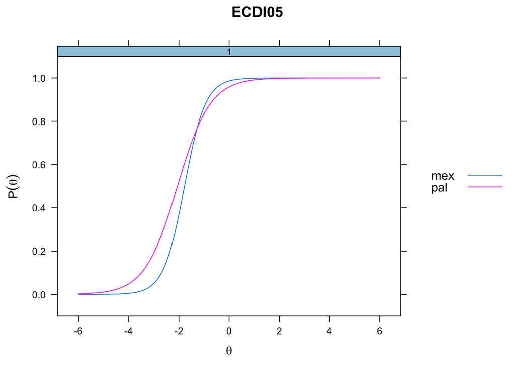

```r
# Focus on ECDI05
invariance <- c("free_mean", "free_var", colnames(dat)[2:11])
dif.ECDI05 <- multipleGroup(dat,
                     model = 1,
                     group = country,
                     itemtype = "2PL" ,
                     invariance = invariance,
                     verbose = F)
itemplot(dif.ECDI05, item = 1, main = "ECDI05")
```

## Further comments

There are a lot of variations on how to the use the LR test and related procedures (Wald test, Lagrange multiplier test) for DIF analysis. The main caveats for all of these procedures have are the same as discussed for the MH test – i.e., deciding which items to use as anchors.

Recent literature has addressed how to avoid the anchor item selection problem. One approach involves testing differences in pairs of items (Bechger & Maris, 2015) which works in principle but does not provide an item-level test (see Yuan et al. 2021 on this point). The other approach involves addressing DIF from the perspective of multi-group scaling (Halpin 2022; Wang et al. 2022). We will discuss the multi-group scaling problem in more detail next time, and may will revisit this topic again then if time permits.

# References and further reading

Holland, P. W., & Wainer, H. (1993). Differential Item Functioning. Lawrence Earlbaum Associates.

Kopf, J., Zeileis, A., & Strobl, C. (2015). Anchor selection strategies for DIF analysis: Review, assessment, and new approaches. Educational and Psychological Measurement, 75(1), 22–56. https://doi.org/10.1177/0013164414529792

Magis, D., Beland, S., Tuerlinckx, F. and De Boeck, P. (2010). A general framework and an R package for the detection of dichotomous differential item functioning. Behavior Research Methods, 42, 847-862. doi: 10.3758/BRM.42.3.847

Millsap, R. E. (2011). Statistical Approaches to Measurement Invariance. Routeledge.

Teresi, J. A., Wang, C., Kleinman, M., Jones, R. N., & Weiss, D. J. (2021). Differential Item Functioning Analyses of the Patient-Reported Outcomes Measurement Information System (PROMIS®) Measures: Methods, Challenges, Advances, and Future Directions. Psychometrika, 86(3), 674–711. https://doi.org/10.1007/s11336-021-09775-0

Zwick, R. (2012). A REVIEW OF ETS DIFFERENTIAL ITEM FUNCTIONING ASSESSMENT PROCEDURES: FLAGGING RULES, MINIMUM SAMPLE SIZE REQUIREMENTS, AND CRITERION REFINEMENT. ETS Research Report Series, 2012(1), i–30. https://doi.org/10.1002/j.2333-8504.2012.tb02290.x

**DIF Without Anchors**

Bechger, T. M., & Maris, G. (2015). A statistical test for differential item pair functioning. Psychometrika, 80, 317–340. https://doi.org/10.1007/s11336-014-9408-y

Halpin, P. F. (2022). Differential item functioning via robust scaling (arXiv:2207.04598). arXiv. https://doi.org/10.48550/arXiv.2207.04598

Wang, W., Liu, Y., & Liu, H. (2022). Testing differential item functioning without predefined anchor items using robust regression. Journal of Educational and Behavioral Statistics, DOI: 10.3102/10769986221109208. https://doi.org/10.3102/10769986221109208

Yuan, K.-H., Liu, H., & Han, Y. (2021). Differential item functioning analysis without a priori information on anchor items: QQ plots and graphical test. Psychometrika, 86, 345–377. https://doi.org/10.1007/s11336-021-09746-5